# Exploratory Data Analysis

### Creating Support Vector Regressor

```python
from sklearn.svm import SVR
```

```python
#Scalling data
from sklearn.preprocessing import StandardScaler
scaler=StandardScaler()
X_train_Scaled=scaler.fit_transform(X_train)
X_test_scaled=scaler.fit_transform(X_test)
```

```python
#Training the model
SVr=SVR()
SVr.fit(X_train_Scaled,y_train)
```

```
SVR()
```

```python
#Predicting y

SVr_y_Predict=SVr.predict(X_test)
```

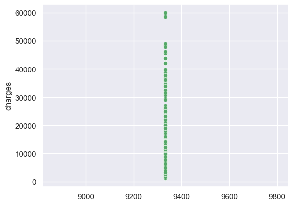

```python
#plotting SVr_y_Predict against y_test
sns.set_style("darkgrid")
sns.scatterplot(x=SVr_y_Predict,y=y_test,color="g")
plt.show()
```

#### SVr Model Evaluation

```python
#Finding Mean Errors
SVr_mae=metrics.mean_absolute_error(y_test,SVr_y_Predict)
SVr_mape=metrics.mean_absolute_percentage_error(y_test,SVr_y_Predict)
SVr_mse=metrics.mean_squared_error(y_test,SVr_y_Predict)
SVr_rmse=np.sqrt(metrics.mean_squared_error(y_test,SVr_y_Predict))
SVr_r2=metrics.r2_score(y_test,SVr_y_Predict)
```

```python
#Displaying Mean errors and r2
print(f"SVr_mae: {SVr_mae}")
print(f"SVr_mape: {SVr_mape}")
print(f"SVr_mse: {SVr_mse}")
print(f"SVr_rmse: {SVr_rmse}")
print(f"SVr_r2: {SVr_r2}")
```

```
SVr_mae: 7769.146049104518
SVr_mape: 0.8757497400590786
SVr_mse: 150106168.6898189
SVr_rmse: 12251.782265850912
SVr_r2: -0.10729216889309545
```

## RMSE and r2 Comparision foir the Models

```python
#Creating Dict for the modesl,RMSE and r2
Reg_Com={"model":("Linear_Regressor_Model","Decision_Tree_Regressor_Model","Random Forest_Regressor_Model",
                  "Support_Vectot_Regressor_Model"),"r2":(Lr_r2,Tr_r2,Rr_r2,SVr_r2)   ,"RMSE":(Lr_mse,Tr_mse,Rr_mse,SVr_mse)}
```

```python
#Conver the Dict to Pandas DataFrame
Reg=pd.DataFrame(Reg_Com)
```

```python
#Display
Reg
```

[output not shown]

[figure not shown]

```python
#Plotting RMSE comparision
plt.figure(figsize=(8,2))
plt.title("RMSE Comparision")
sns.barplot(y="model",x="RMSE",data=Reg)
plt.show()
```

Observations; RandomForesRegressor has the lowest roo mean squared error

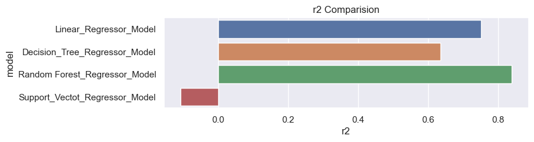

```python
#Plotting r2 Comparision
plt.figure(figsize=(8,2))
plt.title("r2 Comparision")
sns.barplot(y="model",x="r2",data=Reg)
plt.show()
```

Observations; RandomForestRegressor has the lowest root mean squared error and the highest r2 of 0.83 making it the most suitable model . SVR has a -ve r2 even after outliers were eliminated and unnecessary noise eliminated making it unsuitable for the data. From shap observations, smoker and bmi high values push the target to higher positive vallues more than other features. This implies that a smoking individual with high bmi will most likely incur high charges

From feature importance ,smoker and bmi have highest influence on the charges

NB: Random Forest Regressor is most suitable ML model for the data